# Practical Machine Learning Assignment

## Summary

The goal of this machine learning exercise is to predict the manner in which the participants did the exercise, that is to predict the “classe” variable found in the training dataset. The prediction model will then used to predict 20 different test cases.

## Data Processing and Analysis

Loading the required libraries and reading in the training and testing datasets, assign missing values to values that are ‘NA’ or blank.

```r
set.seed(1)
```

```r
datTraining<-read.csv("pml-training.csv", header=TRUE, na.strings=c("NA", ""))
datTesting<-read.csv("pml-testing.csv", header=TRUE, na.string=c("NA", ""))
```

## Data Cleaning

Excluding data with “NA” and delete additional unnecessary columns

```r
library(caret)
datTrainNoNA<-datTraining[, apply(datTraining, 2, function(x) !any(is.na(x)))]
dim(datTrainNoNA)
```

```
## [1] 19622    60
```

```r
datTrainingClean<-datTrainNoNA[,-c(1:8)]
dim(datTrainingClean)
```

```
## [1] 19622    52
```

```r
datTrainNzv <- nearZeroVar(datTrainingClean, saveMetrics=TRUE)
datTrainingCleanNew <- datTrainingClean[,datTrainNzv$nzv==FALSE]
dim(datTrainingCleanNew)
```

```
## [1] 19622    52
```

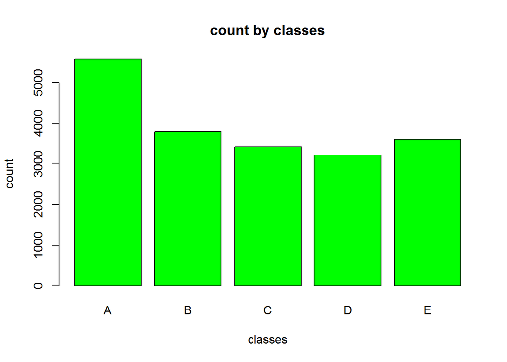

```r
barplot(table(datTrainingCleanNew$classe),ylab="count",xlab="classes",col="green",main="count by classes")
```

## Data Partitioning and Prediction Process

Split the clean training dataset into a training dataset (70% of the observations) and a validation dataset (30% of the observations). This validation dataset is use to perform cross validation when developing the model.

```r
inTrainingData<-createDataPartition(y=datTrainingCleanNew$classe, p=0.70,list=FALSE)
myTrainData <- datTrainingCleanNew[inTrainingData,]
dim(myTrainData)
```

```
## [1] 13737    52
```

```r
myTestData <- datTrainingClean[-inTrainingData,]
dim(myTestData)
```

```
## [1] 5885   52
```

## Prediction Model

Prediction with Random Forests

```r
library(randomForest)
fitControl <- trainControl(method="cv", number=5, allowParallel=T, verbose=T)
rfModel<-train(classe~.,data=myTrainData, method="rf", trControl=fitControl, verbose=F)
print(rfModel)
```

```
## Random Forest
##
## 13737 samples
##    51 predictor
##     5 classes: 'A', 'B', 'C', 'D', 'E'
##
## No pre-processing
## Resampling: Cross-Validated (5 fold)
## Summary of sample sizes: 10988, 10990, 10990, 10990, 10990
## Resampling results across tuning parameters:
##
##   mtry  Accuracy   Kappa
##    2    0.9904634  0.9879353
##   26    0.9906818  0.9882122
##   51    0.9866051  0.9830539
##
## Accuracy was used to select the optimal model using  the largest value.
## The final value used for the model was mtry = 26.
```

# Validate the Model

Using confusionMatrix to evaluate and cross validate the model

```r
predrf<-predict(rfModel, myTestData)
confusionMatrix(predrf, myTestData$classe)
```

```
## Confusion Matrix and Statistics
##
##           Reference
## Prediction    A    B    C    D    E
##          A 1672    7    0    0    0
##          B    1 1130    8    0    0
##          C    1    2 1016   12    1
##          D    0    0    2  952    2
##          E    0    0    0    0 1079
##
## Overall Statistics
##
##                Accuracy : 0.9939
##                  95% CI : (0.9915, 0.9957)
##     No Information Rate : 0.2845
##     P-Value [Acc > NIR] : < 2.2e-16
##
##                   Kappa : 0.9923
##  Mcnemar's Test P-Value : NA
##
## Statistics by Class:
##
##                      Class: A Class: B Class: C Class: D Class: E
## Sensitivity            0.9988   0.9921   0.9903   0.9876   0.9972
## Specificity            0.9983   0.9981   0.9967   0.9992   1.0000
## Pos Pred Value         0.9958   0.9921   0.9845   0.9958   1.0000
## Neg Pred Value         0.9995   0.9981   0.9979   0.9976   0.9994
## Prevalence             0.2845   0.1935   0.1743   0.1638   0.1839
## Detection Rate         0.2841   0.1920   0.1726   0.1618   0.1833
## Detection Prevalence   0.2853   0.1935   0.1754   0.1624   0.1833
## Balanced Accuracy      0.9986   0.9951   0.9935   0.9934   0.9986
```

# Result of the prediction to test dataset

```r
predictpmlTesting<-predict(rfModel, datTesting)

#Output for the prediction of the 20 cases provided
predictpmlTesting
```

```
##  [1] B A B A A E D B A A B C B A E E A B B B
## Levels: A B C D E
```

20/20 cases from the quiz were correctly predicted